# The effects of downsizing on organizational buying behavior: An empirical investigation

Converted from PDF `Lewin-DownsizingOrganizationalBuying-2001-JAMS.pdf` · 14 pages · anchors: page `#pN`, block `#pN-bK`

Page 1

## **The Effects of Downsizing on**

## **Organizational Buying Behavior: An Empirical Investigation**

### **Jeffrey E. Lewin**

*Western Carolina University*

*To survive in today's highly competitive markets, many firms are initiating fundamental changes in organizational form and practice. These restructuring efforts are having*

*significant effects on the organization and management of work within customer firms. However, these important changes have been largely ignored in the extant marketing literature. The research presented in this article first de- scribes a general theory of the effects of organizational downsizing. Then, it examines the potential effects of downsizing on buying center structure and purchase par- ticipant characteristics. Findings support several of the hypotheses related to the proposed effects of organiza- tional downsizing on the outcome variables of interest.*

The pace of organizational change has accelerated, and most organizations now operate within much more com- plex environments (Watkins 1994). In the past, many orga- nizations focused on vertical integration as a means of increasing control in uncertain environments (cf. William- son 1975). Today, however, organizations are finding it less beneficial to own and operate a large number of facto- des or to employ a large number of people (cf. Cascio and Young 1997; Werhane 1999). To survive, many firms are looking for alternatives to hierarchical structures and are altering their form and practice to adapt to rapid change and increased competition. These developments have collec- tively precipitated a shift in the corporate paradigm toward smaller, flexible organizations that can better accommodate novelty, innovation, and change (Bahrami 1992). As a result of these changes, the practice of corporate downsizing has

**Journal of the Academy of Marketing Science. Volume 29, No. 2, pages 151-164. Copyright 9 2001 by Academy of Marketing Science.**

become pervasive. Even as economies expand, downsizing continues, and experts believe that the downsizing trend is far from over (cf. Challenger 1999; Porter 1998)--since much of the change seems to represent permanent shifts in economic and organizational structures (McKinley, Sanchez, and Schick 1995).

Purchasing deparunents have not escaped these trends (Giunipcro, Dawley, and Anthony 1999). Furthermore, the extensiveness of downsizing in procurement has many deeply concerned (Morgan 1997). For example, a recent survey found that 41 percent of purchasers had experi- enced significant downsizing in their departments in recent years (Fitzgerald 1999). In a separate survey, pur- chasers indicated that downsizing had left them woefully shorthanded, leaving existing staff to juggle too many projects, too many deadlines, and too many work hours (Porter 1999). As Michaels, Kumar, and Samu (1995) observe, due to a variety of factors, including downsizing, "purchasing decisions are currently being made under conditions of greater uncertainty than ever before" (p. 11).

For savvy marketers, however, these conditions are creating important opportunities. These opportunities lie in first understanding the changing needs of today's down- sized purchasers and then carefully developing the prod- uct-service combination that best satisfies these needs. Therefore, one major objective of this research is to exam- ine these important issues to provide marketers with insights into how they can refine their offering to best sat- isfy downsized customers' needs. This topic is discussed in greater detail in the Managerial Implications section.

#### **RESEARCH SYNOPSIS**

A considerable amount of attention has been directed toward downsizing in the management and psychology

Page 2

152 JOURNAL OF THE ACADEMY OF MARKETING SCIENCE SPRING 2001

literatures and in the business press (cf. Schmenner and Lackey 1994; Wiesenfeld, Brockner, and Martin 1999). Most of this interest focuses on the benefits expected to accrue to firms embracing such initiatives (cf. Fitzgerald

1999; Simpson 1994), with little attention directed toward downsizing's effects on the roles and functions of survi- vors (Bresnen and Fowler 1994). Moreover, while there currently exists a host of anecdotal articles, empirical stud- ies examining the effects of downsizing are largely absent from the research literature (Luthans and Sommer 1999; Wager 1997).

This lack of attention is especially acute within the marketing research literature, which has virtually ignored these changing dynamics. As Piercy (1998) observes, the "lean enterprise" philosophy largely conflicts with con- ventional marketing approaches, a situation exacerbated by marketing research's failure to respond effectively to widespread corporate downsizing. In addition, Sheth (1996) argues that industry restructuring has caused fun- damental changes in organizational purchasing, creating opportunities for innovative and insightful academic research.

To that end, drawing on threat-rigidity thesis (Staw, Sandelands, and Dutton 1981), classic administration the- try (Blau 1970; Child 1973), and the more recent work of Sutton and D'Aunno (1989), this study investigates the effects of organizational downsizing on buying center struc- ture and purchase participant characteristics. It should be noted, however, that the proposed theory and related out- comes of downsizing studied in this research may be appli- cable to other forms of organizational redesign. ~

The remainder of this article is organized as follows: first, the theoretical underpinnings are reviewed. Then, applying this theoretical grounding, the proposed model and associated hypotheses are developed. Next, the study's methods and results are presented, and finally, the managerial implications of the findings are discussed.

#### **THEORETICAL RELATIONSHIPS**

Threat-rigidity thesis (Staw et al. 1981) posits that decreases in organizational resources (e.g., workforce size) are threatening to organizational members. The anxi- ety generated by such threats is proposed to lead to mecha- nistic structures throughout the organization, as managers seek to consolidate their control. Thus, to the extent that decreasing size is threatening, departments and deci- sion-making groups within downsizing organizations are expected to shift toward more mechanistic structures as manifested through (1) increased centralization of author- ity, (2) increased emphasis on formal rules and procedures, and (3) decreased participative decision making. In con- trast, classic administrative theory suggests that as organi- zations decrease in size, problems of coordination and

control are reduced and can be handled by more organic means, including decentralization of authority, decreased emphasis on formal rules and procedures, and increases in participative decision making (cf. Sutton and D'Aunno

1989). Attempting to reconcile this seemingly contradictory set of expected outcomes, Sutton and D'Aunno (1989) argue that a significant reduction in workforce size evokes both (1) mechanistic shifts in organizational structure due to the increased anxiety among surviving organizational members and (2) at the same time, a decrease in the organi- zation's need for coordination and control brought about by the smaller workforce. These competing forces occur simultaneously, but initially the anxiety produced by workforce reduction will prevail, and the expected mecha- nistic shifts will likely occur. However, once the anxiety provoked by workforce reduction wanes, many of these mechanistic means of coordination and control will be gradually eliminated.

Furthermore, Sutton and D'Aunno (1989) identify three key downsizing characteristics that significantly influence the expected effects: (1) the *degree ofdownsiz- ing,* (2) the *severity of implementation tactics* used to downsize, and (3) members' *negativity in outcome expec- tations* as to the results of downsizing (discussed more fully below). Recent empirical studies have found some support for these downsizing characteristics (cf. Robbins

1999; Wager 1997, 1998). Sutton and D'Aunno (1989) also propose that downsiz- ing firms can be expected to move through two distinct stages. These stages likely will moderate the effects of these three downsizing characteristics. Specifically, dur- ing Stage 1 (Stage 1 firms are defined as firms that are either currently downsizing or have completed downsiz- ing within the past 2 years), the stress and anxiety brought about by greater degrees of downsizing, more severe implementation tactics, and greater negativity in outcome expectations are amplified and lead to increased mecha- nistic structures. However, in the longer term, when down- sizing initiatives are completed and fears of further down- sizing initiatives disappear, the threat abates and organizations move into Stage 2 (Stage 2 firms are defined as firms that have previously completed downsizing, have not implemented downsizing initiatives for 2 or more years, and are not expected to downsize further in the fore- seeable future). This latter shift brings about a change in structure so that more organic means of coordination and control will be adopted throughout the organization. 2

#### **Degree of Downsizing**

The degree of reduction in workforce size may significantly influence the strength of the anticipated effects. For example, Staw et al. (1981) argue that the shift toward mechanistic structures depends on whether the reduction

Page 3

Lewin / EFFECTS OF DOWNSIZING ON BUYING BEHAVIOR 153

represents a significant, fundamental shift in resources or a modest, temporary disruption in an essentially supportive environment. Similarly, Ford and Bacus (1987) observe that if managers perceive reductions in resources as minor and temporary, little or no rigidity may occur. In contrast, large losses in resources may cause managers to construe that they face a significant threat, and resulting rigidities in structures occur. Analogous arguments can be found in the works of Sutton and D'Aunno (1989; D' Aunno and Sutton

1992). In addition, Sutton and Kahn (1987) argue that as the magnitude and duration of downsizing initiatives increase, survivors' perceptions of threat and uncertainty increase as well. These growing stressors lead to greater levels of role conflict and risk aversion and lower levels of organizational commitment.

#### **Severity of Implementation Tactics**

The extent to which workforce reduction is threatening may depend on the implementation tactics through which it is accomplished. Natural attrition and voluntary rede- ployment are often viewed as the least severe tactics and layoff without assistance and abrupt termination the most severe. Sutton and D'Aunno (1989) argue that "layoffs *(i.e., terminations) are* clearly the most threatening form of work force reduction for all groups of surviving employ- ees" (p. 205). The increased threat comes from at least two sources. First, survivors feel guilty because they avoided the fate of their former coworkers; second, survivors worry they will be terminated next if further downsizing is expected (Brockner et al. 1986). In contrast, downsizing through natural attrition or voluntary redeployment is much less threatening since survivors have no reason to feel either guilty or anxious (Sutton and D'Aunno 1989). Thus, it is expected that the use of severe strategies will be more threatening to survivors and provoke more pro- nounced and longer lasting mechanistic shifts in structure. In addition, the use of severe strategies likely will increase levels of role conflict and risk aversion and decrease levels of organizational commitment felt by survivors. Support for these arguments can be found in the work of Brockner, DeWitt, Grover, and Reed (1990); Brockner et al. (1994); and Wager (1997 ).

#### **Negativity of Outcome Expectations**

Finally, organizational members' expectations of the outcomes related to downsizing can influence the pre- dicted effects. For example, members may perceive down- sizing as a "necessary evil" needed to ensure the firm's long-term health (Mishra and Spreitzer 1998). To the extent that such positive perceptions are collectively held, it is expected that downsizing will lead to less rigidity in structure and that the transition to more organic structures likely will occur more quickly (Sutton and D'Aunno

1989). In contrast, uncertainty surrounding downsizing is likely to increase when survivors believe that downsizing was avoidable, question the legitimacy of the decision to downsize, and begin to speculate that the organization will take additional questionable actions (Brockner et al.

1990). In these situations, as survivors develop negative outcome expectations--believing that downsizing will result in a weakened organization--greater rigidity is expected and will likely continue until these collective negative perceptions subside (Sutton and D'Aunno 1989). These negative perceptions also are expected to increase survivors' levels of role conflict and risk aversion and decrease levels of organizational commitment. Limited support for these propositions is found in the work of Brockner et al. (1990) and Wager (1997).

#### **DOWNSIZING'S EFFECT ON ORGANIZATIONAL BUYING BEHAVIOR**

Furthermore, these anticipated effects are expected to be moderated by the stage of downsizing the organization is currently in. That is, the influence of degree of downsiz- ing, severity of implementation tactics, and negativity of outcome expectations on buying center structure and pur- chase participant characteristics are expected to be greater within Stage 1 organizations as compared with Stage 2 organizations. The specific hypotheses related to downsiz- ing's effects on organizational buying behavior will now be discussed in more detail.

#### **Downsizing and Buying Group Structure**

The concept of the organizational buying center has generated numerous research studies (cf. Johnston and Bonoma 1981; McQuiston 1989). A significant number of

Page 4

I54 JOURNAL OF THE ACADEMY OF MARKETING SCIENCE SPRING 2001

these prior studies concentrated on three aspects of buying center structure: centralization, formalization, and partici- pation in decision making 3 (cf. Barclay 1991; Spekman and Stem 1979). One construct found to consistently and significantly influence buying center structure is the extent of threat or uncertainty facing these decision-making groups (of. Dwyer and Welsh 1985; Kohli 1989).

Combining this prior research with Sutton and D'Aunno's (1989) general theory, it is posited here that the uncertainty created by downsizing is perceived as threat- ening to organizational members (of. Brockner et al. 1990; Mishra and Spreitzer 1998). In response to this threat and uncertainty, buying centers in downsized organizations are expected to exhibit more mechanistic structures, espe- cially buying centers within Stage 1 organizations. How- ever, as organizations transition to Stage 2, buying centers within these organizations are expected to exhibit less mechanistic structures (more organic structures). Thus, the following suggestions are made:

*Proposition 1:* Degree of downsizing will be positively

related to buying center (I) centralization of authority and (2) emphasis on formal rules and procedures and negatively related to (3) participative decision making. *Hypothesis 1: The* strength of the predicted relationships

between degree ofdownsizing and (1) centralization of authority, (2) emphasis on formal rules and proce- dures, and (3) participative decision making will be greater for buying centers within Stage 1 organiza- tions compared with buying centers within Stage 2 organizations. *Proposition 2:* Severity of implementation tactics will be

positively related to buying center (1) centralization of authority and (2) emphasis on formal rules and procedures and negatively related to (3) participative decision making. *Hypothesis 2: The* strength of the predicted relationships

between severity of implementation tactics and (1) centralization of authority, (2) emphasis on formal

rules and procedures, and (3) participative decision making will be greater for buying centers within Stage 1 organizations compared with buying centers within Stage 2 organizations. *Proposition 3:* Negativity of outcome expectations will

be positively related to buying center (1) centralization of authority and (2) emphasis on formal rules and procedures and negatively related to (3) participative decision making. *Hypothesis 3: The* strength of the predicted relationships

between negativity of outcome expectations and (1) centralization of authority, (2) emphasis on formal rules and procedures, and (3) participative decision making will be greater for buying centers within Stage 1 organizations compared with buying centers within Stage 2 organizations.

#### **Downsizing and Purchase Participant Characteristics**

Purchase participant characteristics also have been studied extensively in the marketing literature. Of the vari- ous characteristics previously studied, role conflict, risk aversion, and organizational commitment are examined here. 4

#### **Participant Role Conflict**

The importance of role conflict has been recognized within the marketing literature (e.g., Barclay 1991; Michaels, Day, and Joachimsthaler 1987). Because pur- chasers must interact frequently with people from other departments and organizations, as well as accommodate requests from a variety of internal and external constitu- ents, they experience role conflict due to often incongru- ous and/or vague expectations (of. Michaels and Dixon

1994; Michaels et al. 1995). According to Brockner, Grover, Reed, DeWitt, and O'Malley (1987), as firms downsize, there is great poten- tial for a type of role conflict known as role overload, 5 as the number of tasks to be accomplished remains constant, but fewer people are available to accomplish these tasks. Simultaneously, to enhance their job security, survivors often feel the need to demonstrate superior performance (Isabella 1989; Robbins 1999). As these expectations place insurmountable demands on surviving employees, they often experience role conflict via role overload. Pur- chase participants in downsizing organizations are partic- ularly susceptible to role overload as they must accom- plish a greater portion of departmental tasks, in addition to the tasks defined by their roles within the buying center.

Furthermore, the extent to which an organization's work activities are defined by formal rules and procedures has been linked to role conflict both conceptually **and** empirically (e.g., Michaels et al. 1987; Nicholson and Goh

1983). Therefore, if (as expected) there is an initial shift to more mechanistic structures, then the resulting emphasis on the use of formalized rules and procedures is likely to

Page 5

Lewin / EFFECTS OF DOWNSIZING ON BUYING BEHAVIOR 155

increase role conflict among buying center participants. However, as Stage 2 organizations adopt more organic structures, role conflict should abate as purchase partici- pants begin to enjoy more job-related autonomy and flexi- bility in decision making.

Participant Risk Aversion

The role of risk and risk handling strategies as significant elements of industrial purchasing has been demon- strated in prior research (e.g., Henthorne, LaTour, and Williams 1993; Puto, Patton, and King 1985). The ten- dency toward risk aversion among buying center partici- pants is a consistent finding across these studies. More recently, Hyman (1995) reports that in downsized firms, purchasers are often pressured to increase productivity, meet restrictive deadlines, and mediate increased conflict between internal customers and external suppliers. As a result of these stressful situations, purchasers become increasingly risk averse. In addition, Wager (1998) found that survivors spend much of their time struggling under the weight of more work and avoiding anything that approaches risk taking. Instead, surviving purchasers develop a nearly compulsive concern with following rules and procedures, become obsessive about risk avoidance, and strive exorbitantly to accommodate all concerned (Hyman 1995; Robbins 1999). Similar findings are reported by Fombrun and Ginsberg (1990) and Hitt, Keats, Harback, and Nixon (1994). Therefore, it seems reason- able to expect that buying center participants involved in an important purchase decision and working in downsiz- ing organizations will become increasingly risk averse.

Participant Organizational Commitment

As a result of downsizing, purchasing decisions are now made under conditions of greater uncertainty and stress. In their study of 330 purchasing professionals, Michaels et al. (1995) found that increased job-related stress (due to factors including downsizing) was positively correlated with decreased organizational commitment among purchasers. These findings are similar to those of Brockner et al. (1987), who found that downsizing initia- tives result in decreased organizational commitment on the part of downsizing survivors. As a result, the organization becomes increasingly vulnerable to defections, further decreasing survivor commitment (Hitt et al. 1994; Porter

1999). Additional empirical support for these decreased levels of organizational commitment can be found in the research of Brockner et al. (1994), Wager (1998), and Luthans and Sommer (1999).

Moreover, motivation theorists posit that individuals work within firms to receive rewards. Several studies pro- vide support for this perspective and its impact on pur- chase participants (e.g., Chambers, Anderson, and Dunlap

1986; McQuiston and Dickson 1991). However, today's downsized firms provide fewer opportunities for extrinsic

rewards (i.e., promotion, advancemenO, and neither their mechanistic structures nor threatening climates are condu- cive to the realization of intrinsic rewards. Therefore, it is unlikely that survivors will be committed to the organiza- tion. The preceding discussions suggest the following:

*Proposition 4:* Degree of downsizing will be positively

related to purchase participant (1) role conflict and (2) risk aversion and negatively related to (3) organi- zational commitment. *Hypothesis 4: The* strength of the predicted relationships

between degree of downsizing and (1) role conflict, (2) risk aversion, and (3) organizational commit- ment will be greater for buying centers within Stage

1 organizations compared with buying centers within Stage 2 organizations. *Proposition 5:* Severity of implementation tactics will be

positively related to purchase participant (1) role conflict and (2) risk aversion and negatively related to (3) organizational commitment. *Hypothesis 5: The* strength of the predicted relationships

between severity of implementation tactics and (1) role conflict, (2) risk aversion, and (3) organiza- tional commitment will be greater for buying cen- ters within Stage 1 organizations compared with buying centers within Stage 2 organizations. *Proposition 6:* Negativity of outcome expectations will

be positively related to purchase participant (1) role conflict and (2) risk aversion and negatively related to (3) organizational commitment. *Hypothesis 6: The* strength of the predicted relationships

between negativity of outcome expectations and (1) role conflict, (2) risk aversion, and (3) organiza- tional commitment will be greater for buying cen- ters within Stage 1 organizations compared with buying centers within Stage 2 organizations.

#### **Measure Development and Purification**

Seven multi-item measures (initially containing five to seven items each) were used to investigate the perceptual relationships of interest in this study (see the appendix). In addition, one two-item and two single-item measures were used to assess stage of downsizing, degree of downsizing, and implementation tactics used to downsize3 Of the seven multi-item measures, six were adapted from previ- ous empirical studies (i.e., centralization of authority, for- mal rules and procedures, participative decision making, role conflict, organizational commitment, and negative outcome expectations), and one was newly developed (to measure risk aversion). The single, newly developed scale was based on an extensive review of the relevant literature and interviews with academicians and purchasing professionals.

Page 6

156 JOURNAL OF THE ACADEMY OF MARKETING SCIENCE SPRING 2001

In addition, two pretests were performed to further refine the selected items. First, seven academicians were asked to review the proposed items for clarity and repre- sentativeness based on their knowledge and experience. Second, iterative personal interviews were conducted with 20 purchasing managers employed in a large metropolitan area. Each purchasing professional answered the ques- tionnaire and, as they read the questions and instructions, verbalized any thoughts that came to mind (e.g., ambigu- ity, inapplicability). All elements of the questionnaire's instructions, items, and format were revised based on each personal interview until no further changes were suggested.

Also, as is customary, introductory statements were included in key sections of the questionnaire. For example, the following statement appeared at the beginning of the section focusing on buying center structure: "When answering the following questions please consider a pur- chase decision (1) where the outcome is of *considerable importance to your company* and (2) that requires the input and involvement of people from several departments or functional units (a *buying group)* within the company." Similarly, the following statement appeared at the begin- ning of the section focusing on purchase participant char- acteristics: "We are interested in your perceptions or beliefs about the current work environment within your company. When answering the following questions please think of that part of the company for which your depart- ment has buying responsibility." Each of these introduc- tory statements was pretested using the methods discussed in the preceding paragraph.

Prior to hypotheses testing, unidimensionality, reliability, and convergent and discriminant validity were assessed for each individual measure, as well as each group of theoretically related measures (Gerbing and Anderson 1988; J/Sreskog and SiSrbom 1989). First, item-to-total correlations were examined for the items in each measurement scale. Items with low correlations were deleted if they tapped no additional domain of interest. Next, confirmatory factor analyses were performed on items from subsets of theoretically related measures (based on the proposed hypotheses) to assess unidimen- sionality. 7 Finally, models ranging from one to n factors were estimated, with n corresponding to the number of hypothesized measures. Without exception, the models representing the predicted number of constructs were superior to all other models estimated as indicated by their individual goodness-of-fit indices (X 2) and low cross- loadings between constructs (Moorman, Deshpand6, and Zaltman 1993). Table 1 contains the properties of the puri- fied measures.

In addition, discriminant validity was examined by analyzing the Pearson correlation coefficients among con- structs. Following previous research, discrimination is

**TABLE 1 Properties of Purified Measures**

[output not shown]

NOTE: table converted from PDF layout to HTML text; cell boundaries are reconstructed. See PDF if exact alignment matters.

a. Single-item measures; hence, alphas are not reported. b. Items were measured using a Likert-type scale where 1 = *strongly dis- agree and 7 = strongly agree.* c. Dummy coded: Stage 1 = 1, Stage 2 = 0.

achieved "when each correlation is less than 1.0 by an amount greater than twice its respective standard error" (cf. Tax, Brown, and Chandrashekaran 1998:67). All pairwise correlations are less than 1 by amounts signifi- cantly greater than twice their respective standard errors (see Table 2).

#### **Procedure**

The sampling frame consisted of all members of the National Association of Purchasing Management of Geor- gia (NAPM-GA). Included with their monthly newsletter, each member (513) of NAPM-GA was mailed a survey, along with a cover letter and a self-addressed, prepaid return envelope. A similar second mailing was included with the following month's newsletter. To foster response rates, respondents could choose to be included in a lottery drawing for 1 of 10 cash prizes ranging from $50 to $500. The combined mailings produced 215 usable question- naires (41.9%). Of these, 31 were from firms that had never downsized, 124 were from Stage 1-type firms, and 60 were from Stage 2-type firms. Response bias was assessed in two ways. First, the sample was split into early and late responses. Then, responses were compared on all key variables, and no significant differences were found. Second, the sample was split into Stage 1 and Stage 2 orga- nizations. Then, all organization (e.g., sales, income, num- ber of employees) and respondent (e.g., age, education,

Page 7

Lewin / EFFECTS OF DOWNSIZING ON BUYING BEHAVIOR 157

**TABLE 2 Correlations Among Constructs**

[output not shown]

NOTE: table converted from PDF layout to HTML text; cell boundaries are reconstructed. See PDF if exact alignment matters.

NOTE: Pearson correlation coefficient *(SE* in parentheses). BGAUTH = centralization of authority; BGRULS = emphasis on rules and procedures; BGDECS = participation in decision making; ROLE= role conflict; RISK = risk aversion; ORGCOM = organizational commitment; DEGDWN = degree of downsizing; IMPDWN = severity of implementation tactics; OUTCOM = negativity of outcome expectations; STAGE = stage of downsizing. Where the correlations between constructs are high, in no case am the intercorrelated constructs copredictors of a dependent variable (Hair, Anderson, Tatham, and Black 1992). *p < .01. **p < .05. ***p < .10.

years of purchasing experience) demographic data were compared, and no significant differences were found)

#### **RESULTS**

To test the hypotheses, it was necessary to estimate the main effects that the predictor variables degree of down- sizing, severity of implementation tactics used to down- size, and negativity in outcome expectations have on the six criterion variables associated with buying center struc- ture and purchase participant characteristics (e.g., central- ization of authority, role conflict). In addition, it was nee- essary to examine the moderating (interaction) effects between stage of downsizing and the three predictor vari- ables (e.g., degree, severity, negativity) on the six criterion variables.

An appropriate statistical method to estimate these effects is multiple regression analysis. As part of the initial regression analysis, several diagnostic tests, graphs, and scatterplots of the residuals were used to test the assump- tions of normality, linearity, and homoscedasticity. An examination of the results of these tests and plots suggests that these assumptions were appropriate. Furthermore, an examination of additional diagnostic tests indicated no serious multicollinearity problems.

Therefore, a series of six ordinary least squares (OLS) regression models were estimated (see Table 3). The

where Y= centralization of authority, X 1 = degree of downsizing, X 2 = severity of implementation tactics, X 3 = negativity in outcome expectations, and X 4 = stage of downsizing.

**Hypothesis 1: Relationship Between Degree of Downsizing and Buying Center Structure Moderating Effect of Stage of Downsizing**

Hypothesis 1 states that the strength of the predicted relationships between degree of downsizing and (1)

Page 8

158 JOURNAL OF THE ACADEMY OF MARKETING SCIENCE SPRING 2001

centralization of authority, (2) emphasis on formal rules and procedures, and (3) participative decision making will be greater for buying centers within Stage 1 organizations compared with buying centers within Stage 2 organiza- tions. Statistical support is found for the hypothesized moderating effect of the relationship between degree of downsizing and centralization of authority (13 = .54, p < .01) and degree of downsizing and participative decision making (1~ = -.42,p < .05).

**Hypothesis 2: Relationship Between Implementation Tactics and Buying Center Structure Moderating Effect of Stage of Downsizing**

Hypothesis 2 states that the strength of the predicted relationships between severity of implementation tactics and (1) centralization of authority, (2) emphasis on formal rules and procedures, and (3) participative decision mak- ing will be greater for buying centers within Stage 1 orga- nizations compared with buying centers within Stage 2 organizations. Statistical support is found for the hypothe- sized moderating effect of the relationship between imple- mentation tactics and centralization of authority (1~ = .53, p < .05).

**Hypothesis 3: Relationship Between Outcome Expectations and Buying Center Structure Moderating Effect of Stage of Downsizing**

Similarly, Hypothesis 3 states that the strength of the predicted relationships between negativity of outcome expectations and (1) centralization of authority, (2) emphasis on formal rules and procedures, and (3) participative decision making will be greater for buying centers within Stage 1 organizations compared with buy- ing centers within Stage 2 organizations. No statistical support is found for these hypothesized moderating effects. Statistical support is, however, found for negativity of outcome expectations' positive main effect on centralization of authority (13 = .28, p < .01) and nega- tive main effect on participative decision making (I] =-. 14, p <. 10) within buying centers.

**Hypothesis 4: Relationship Between Degree of Downsizing and Purchase Participant Characteristics--Moderating Effect of Stage of Downsizing**

Hypothesis 4 states that the strength of the predicted relationships between degree of downsizing and (1) role conflict, (2) risk aversion, and (3) organizational commit- ment will be greater for buying centers within Stage 1 organizations compared with buying centers within Stage 2

organizations. Statistical support is found for the hypothesized moderating effect of the relationship between degree of downsizing and organizational commitment (13 = -.28, p < .10). In addition, statistical support is found for degree

of downsizing's positive main effect on role conflict (13 = .12,p< .10).

**Hypothesis 5: Relationship Between Implementation Tactics and Purchase Participant Characteristic~Moderating Effect of Stage of Downsizing**

Hypothesis 5 states that the strength of the predicted relationships between severity of implementation tactics and (1) role conflict, (2) risk aversion, and (3) organiza- tional commitment will be greater for buying centers within Stage 1 organizations compared with buying cen- ters within Stage 2 organizations. No statistical support is found for these hypothesized effects.

**Hypothesis 6: Relationship Between Outcome Expectations and Purchase Participant Charecteristics -Moderating Effect of Stage of Downsizing**

Similarly, Hypothesis 6 states that the strength of the predicted relationships between negativity of outcome expectations and (1) role conflict, (2) risk aversion, and (3) organizational commitment will be greater for buying cen- ters within Stage 1 organizations compared with buying centers within Stage 2 organizations. No statistical support is found for these hypothesized moderating effects. Statis- tical support is, however, found for negativity of outcome expectations' positive main effect on purchase participant role conflict (~ = .58,p < .01) and risk aversion (1~ = .41,p <

.01), as well as negative main effect on purchase participant organizational commitment ([~ = -.46, p < .01).

#### **DISCUSSION**

Briefly, based on the sociology, psychology, and marketing literatures, the major thesis of this research is that the anxiety produced by organizational downsizing leads to shifts in the way departments and work groups within downsized firms are structured and managed. Further- more, it is posited that these anxieties and shifts lead to changes in buying center structure and purchase partici- pant characteristics. It also is argued that the intensity and duration of the expected effects likely will be significantly influenced by the degree of downsizing that has taken place, the severity of implementation tactics used to accomplish downsizing, and the negativity of outcome expectations held by organizational members. Finally, it is proposed that the impact of downsizing will be greater

Page 9

Lewin / EFFECTS OF DOWNSIZING ON BUYING BEHAVIOR 159

**TABLE 3 Standardized Regression Coefficients (hypotheses tests)**

[output not shown]

NOTE: table converted from PDF layout to HTML text; cell boundaries are reconstructed. See PDF if exact alignment matters.

within Stage 1 organizations as compared with Stage 2 organizations.

#### **Findings: Moderating Effect of Stage of Downsizing**

Findings related to the moderating effects of stage of downsizing indicate that in those Stage 1 organizations experiencing higher degrees of downsizing, sellers can expect to find increased levels of centralization of author- ity and decreased levels of participative decision making within buying centers. Also, greater centralization of authority within buying centers will be found in those Stage 1 organizations using more severe implementation tactics to accomplish downsizing. In addition, findings indicate that higher degrees of downsizing in Stage 1 orga- nizations also will result in decreased levels of organiza- tional commitment among purchase participants.

#### **Findings: Main Effect of Downsizing Characteristics**

Findings related to the main effect of downsizing characteristics (i.e., degree of downsizing, severity of imple- mentation tactics, and negativity of outcome expectations) indicate that both greater degrees of downsizing and greater negativity of outcome expectations will increase levels of role conflict among purchase participants in downsized organizations. Furthermore, greater negativity of outcome expectations also will increase levels of risk aversion and decrease levels of organizational commit- ment among purchase participants. In addition, findings indicate that greater negativity of outcome expectations will increase centralization of authority and decrease participative decision making within the buying centers of downsized organizations.

#### **Managerial Implications**

In today's environment, marketers increasingly search for ways to better satisfy customers' needs. To that end, some of the findings reported here may provide insights to help marketers refine their efforts. For example, increased levels of centralization of authority and decreased levels of participative decision making in the buying groups of Stage 1 downsizing firms (especially those experiencing high degrees of downsizing and/or using more severe tac- tics to downsize) suggest that marketing efforts should be directed toward upper-level managers within these buying organizations very early in the purchase process. That is not to say other buying group members should be bypassed. Rather, it emphasizes the importance of not relying solely on efforts to reach front-line buying group participants. In contrast, in Stage 2 firms characterized by less centralization of authority and more participative decision making, early direct targeting of upper-level managers may be inappropriate.

Additional findings providing insight into refining the marketing approach can be found in the increased levels of role conflict and risk aversion found in downsized firms---especially those experiencing greater degrees of downsizing and/or greater negative outcome expectations. First, when purchase professionals are experiencing role overload, key motivators often include the ability to save time and simplify purchasing and inventory management processes. Suppliers can help by offering supplier-man- aged inventory solutions, electronic information-sharing systems, and rapid response strategies to accommodate changing customer demand (e.g., through inventory buff- ers and flexible warehousing, distribution, transportation systems). However, a word of caution is warranted. If downsizing initiatives were *cost driven only,* marketers need to ensure that these types of added customer services

Page 10

160 JOURNAL OF THE ACADEMY OF MARKETING SCIENCE SPRING 2001

also will result in benefits to the vendor (e.g., greater volume, improved margins).

Second, as levels of role conflict increase, vendors should place greater emphasis on helping purchase partici- pants reduce conflict and reach consensus. One way this might be accomplished is by providing improved support materials to all buying group members (i.e., cost-benefit analyses, user-friendly product specifications, technical information sources, and product demonstrations). In addition, when purchase participants are exceptionally risk averse, as may be the case especially when survivors hold more negative outcome expectations, the importance of price diminishes in favor of risk-reducing features in the offering. These types of features might include perfor- mance guarantees, extended warranties, on-site installation, and on-site and remote technical assistance (24 hours/7 days). Also, highly risk-averse buying group members likely will favor known vendors and proven products. In contrast, buying groups in Stage 2 firms, where *intelligent* risk taking is encouraged, may be more likely to be recep- tive to adopting new products or technologies.

Finally, it is important to note that before various marketing strategies can be used, one must ascertain which of the two stages the downsized buying finn is in. Like most effective sales and marketing efforts, reliable customer in- formation is key. Some of the more important questions to ask include the following:

9 What was the total percentage reduction in the firm's

workforce? In the purchasing department? 9 How many downsizing initiatives did it take to ac-

complish this total workforce reduction? Purchasing department reduction? 9 Over what period of time did these downsizing ini-

tiatives take place? 9 What was the predominant method used to reduce

the workforce? The purchasing department? 9 What is the general organizational climate among

survivors, and what are their expectations for the future health of the firm? What are the expectations of survivors in the purchasing department?

9 Do survivors feel that downsizing was necessary

and will accrue needed benefits to the firm?

#### **Research Contributions and Limitations**

One contribution of this research is that it provides the first major test of Sutton and D'Aunno's (1989) explana- tion for the divergent predictions and findings offered by the threat-rigidity thesis and classic administration theory. Another contribution of this research is that it builds on Brockner et al.'s (1987, 1994) examination of the effects of organizational downsizing and extends that work into the domain of marketing. The findings reported here regard- ing purchase participants' levels of role conflict, risk aver- sion, and organizational commitment provide additional support for these previous works in a different research context, thus potentially increasing the validity of their findings. This research also adds to the rich body of litera- ture and knowledge focusing on business-to-business mar- keting in general and organizational buying behavior in particular.

Among potential limitations, while the results of the tests used to assess reliability and validity of scales in this study provide some level of confidence, there is a need for further testing using different samples and multiple meth- ods for further verification. Also, the assumption is made that purchasing professionals working within respondent organizations are in a position to accurately assess and report the impact downsizing has had on buying group structure and purchase participant characteristics. The problems surrounding the use of key informant data have been discussed throughout the literature (cf. John and Reve 1982; Phillips 1981). Yet, reliance on key informant data continues to be a widely used methodology.

Finally, a limitation and a contribution of this work lie in the fact that some of the constructs investigated here have not been examined before in the context of organiza- tional buying behavior. Therefore, the results and implica- tions presented must be viewed with a certain amount of reservation.

#### **APPENDIX Final Measures and Items**

#### **1. Centralization of Authority (adapted from Barclay 1991; McCabe 1987) ~**

1. Decisions made by the buying group are subject to review by management prior to final approval. 2. Going through the proper channels of authority is stressed throughout the purchase process. 3. Buying group members rarely have the authority to exercise their own judgment during the purchase process.

#### **2. Formal Rules and Procedures (adapted from Barclay 1991; McCabe 1987)**

1. In this company, the buying group must follow strict procedures. 2. Throughout the purchase process, buying group members are expected to follow existing rules. 3. Management is very strict with regard to following written rules and procedures throughout the purchase process.

Page 11

Lewin / EFFECTS OF DOWNSIZING ON BUYING BEHAVIOR 161

#### **3. Participative Decision Making (adapted from McCabe 1987)**

1. The highest ranking members of the buying group often make purchase-related decisions without consulting other buying group members) 2. Decisions related to buying roles and responsibilities often are made without individual buying group member involvement, b 3. Buying group members' suggestions concerning how to proceed are rarely given careful consideration before action is taken, b

#### **4. Risk Aversion--New Scale**

1. This company discourages its employees from taking risks. 2. If I were to make a bad decision, my status within the company could be jeopardized. 3. In this company, it is better to play it safe than to take a chance. 4. In this company, there is little tolerance for errors or mistakes.

#### **5. Role Conflict (adapted from Michaels, Cron, Dubinsky, and Joachimsthaler 1988)**

1. I receive an assignment without the manpower to complete it. 2. I receive incompatible requests from two or more people. 3. I receive an assignment without adequate resources to execute it.

#### **6. Organizational Commitment (adapted from Michaels et al. 1988)**

1. I talk up this company to my friends as a great company to work for. 2. I find my values and this company's values are very similar. 3. This company really inspires the very best in me in the way of job performance.

#### **7. Negative Outcome Expectations (adapted from Thomas, Clark, and Gioia 1993)**

1. Downsizing will not result in the objectives this company hopes to achieve. 2. It is unlikely that overall this company will gain a great deal from downsizing. 3. The extent to which this company has downsized has negative implications for the future. 4. Downsizing will have an overall negative effect on this company.

#### **8. Degree of Downsizing---New Scale**

In your opinion, which of the following best describes the total amount your company has downsized over the past 10 years?

None [] 1%-15% [] 16%-30% [] Greater than 30% []

#### **9. Implementation Tactics (suggested by Greenhalgh, Lawrence, and Sutton 1988)**

In your opinion, which "one" of the following best describes the predominant method used by your company to accomplish its

downsizing goals? (Please choose only one)

| Natural | Voluntary | Involuntary | Layoffwith | Layoffwithout | Abrupt |
| --- | --- | --- | --- | --- | --- |
| attrition | redeployment | redeployment | assistance | assistance | termination |
| [] | [] | [] | [] | [] | n |

NOTE: table converted from PDF layout to HTML text; cell boundaries are reconstructed. See PDF if exact alignment matters.

#### **10. Stage of Downsizing--New Scale**

Please check the following period(s) your current company was in the process of downsizing. (Please check as many periods as appropriate)

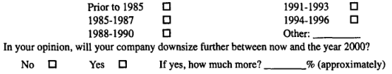

NOTE: complex table shown as an image of the PDF; the text below is a rough machine extraction and may be mis-aligned.

**extracted text (unreliable layout)**

Prior to 1985 [] 1991 -1993 [] | 1985 1987 [] 19941996 [] - - | 1988 -1990 [] Other: | Inyouropinion willyourcompanydownsizefurtherbetweennowandtheyear20007 , | No [] Yes [] Ifyes howmuchmore? %(approximately) ,

a. Above items 1-7 used the scale *1 = strongly disagree, 4 = neither agree nor disagree, 7 = strongly agree.* b. Reverse coded.

Page 12

162 JOURNAL OF THE ACADEMY OF MARKETING SCIENCE SPRING 2001

#### **ACKNOWLEDGMENTS**

**This research was supported by a grant from the National Association of Purchasing Management.**

#### **NOTES**

1. Downsizing often occurs as a direct result of corporate mergers. For example, in December 1998, Citigroup announced plans to cut

10,400 workers (6% of the company's workforce) as a result of the merger between Citicorp and Travelers Group, Inc. In December 1998, MCI WorldCom, Inc. announced plans to cut 3,750jobs (5% of the com- pany's workforce) as a result of WorldCom's merger with MCI Corp. Ad- ditional downsizing initiatives directly related to mergers include Compaq Computer's merger with Digital Equipment (17,000 jobs cut), Exxon's merger with Mobil (12,000 jobs cut), NationsBank's merger with BankAmerica (8,000jobs cut), and British Petroleum's merger with Amoco (6,000 jobs cut).

Downsizing initiatives are also frequently associated with corporate takeovers. For example, in December 1998, Seagram Co. announced plans to cut 3,000jobs as a result of its takeover of PolyGram NV (20% of PolyGram's total workforce). Similarly, in November 1998, as part of its takeover of Banker's Trust, Deutshe Bank announced plans to cut ap- proximately 5,500 jobs in New York and London.

Finally, downsizing is often linked directly to corporate restructuring efforts. For example, in December 1998, Johnson & Johnson announced plans to cut 4,100jobs (4% of its workforce) as part of an $800 million re- structuring effort. In November 1998, Texaco announced plans to cut 1,000jobs (5% of its workforce) in a restructuring effort designed to save approximately $200 million annually. Similar downsizing initiatives are linked to recent restructurings at Polaroid Corp., Diebold, D. E. Shaw & Co., and Levi Strauss & Co.

2. It should be noted that in recent years, several theoretical models have been developed and/or applied to various aspects of organizational downsizing. For example, the concepts of "procedural and distributive justice" have been adapted from the psychology literature and used to

help explain the variance in survivors' responses to downsizing (cf. Brockner et al. 1990). Similarly, the Lazarus theory of stress is used by Mishra and Spreitzer (1998) to help explain the factors that influence sur- vivors' responses to downsizing.

However, while these competing (or, perhaps, complementary) theoretical models provide useful explanatory contributions, none addresses the constructs of interest in this study (i.e., centralization, formalization, participation, role conflict, risk aversion, organizational commitment) as directly as Sutton and D'Aunno's work (Sutton and D'Aunno 1989; D'Aunno and Sutton 1992).

It is also interesting to note that some of these other theoretical models incorporate some of the same explanatory constructs discussed by Sutton and D'Aunno (1989) and examined empirically in the study pres- ent here. These shared constructs include role conflict (i.e., "role over- load"), outcome expectations (i.e., "trust in management"), and implementation tactics (i.e., "perceived justice") as described in Mishra and Spreitzer (1998), as well as implementation tactics (i.e., "organiza- tional caretaking"), organizational commitment (i.e., "organizational commitment"), and Stage 1 to Stage 2 transition (i.e., "likelihood of fu- ture layoffs") as described in Broekner et al. (1990).

*3. Centralization--the* degree to which authority, responsibility, and power are concentrated within the decision-making unit. *Formaliza- tion---the* extent to which activity in a buying group is formally pre- scribed by rules and procedures. *Participationhthe* extent to which rep-

resentatives from various departments and/or functional units are directly involved in a purchase decision.

*4. Role conflict--the* degree of congruency or compatibility in the requirements of job-related roles relative to a set of standards or conditions that impinge on role performance. *Risk aversion---the* degree to which purchase participants believe it is best to play it safe and avoid taking risks, especially if they may be penalized if a wrong decision is made. Or- *ganizational commitment--the* relative strength of an individual's identi- fication with and involvement in his or her organization.

*5. Role overload--the* extent to which various tasks exceed the amount of time and resources available for their accomplishment.

6. The one two-item and two single-item measures were used to investigate matters of fact rather than perceptual or conceptual constructs. These items included stage of dowusizing, degree of downsizing, and imple- mentation tactics used to downsize. Throughout the sequence of pretest interviews, it was clear that respondents were able to answer these three questions with little hesitation and with great confidence of accuracy.

First, the difference between Stage 1 and Stage 2 organizations was determined by asking respondents the following: (1) during what years did your company engage in the process of downsizing? and (2) do you believe your company will downsize further between now and the year 2000 (which represented a 2-plus year period at the time the surveys were administered)? If the respondent indicated that his or her company had downsized in the recent past (i.e., 1991-1996) and was expected to down- size between 1997 and 2000, then the firm was considered a Stage 1 orga- nization. Similarly, if the respondent indicated that his or her company had downsized between 1994 and 1996 (regardless of future downsizing plans), the firm was considered a Stage 1 organization. If the respondent indicated that his or her company had not downsized since 1993 and was not expected to dowusize further between 1997 and 2000, then the firm was considered a Stage 2 organization. Finally, if the respondent indi- cated his or her company had never downsized (31 of total), the survey was eliminated.

Second, for degree of downsizing, respondents were asked to indicate the total amount (expressed as a percentage) their company had down- sized over the past 10 years. Virtually all downsizing initiatives are re- ported by companies as to both total numbers of jobs to be cut and the percentage of the current workforce that total number represents (e.g., "Goodyear m slash 2,800 workers, equal to 3% of its global workforce" [February 3, 1999]).

Third, respondents were asked to identify the predominant method used by their company to accomplish its downsizing goals. The choice was among six implementation tactics: natural attrition, voluntary rede- ployment, involuntary redeployment, layoff with assistance, layoff with- out assistance, and abrupt termination.

7. This procedure follows Moorman, Deshpand6, and Zaltman (1993), who suggest it as a means of overcoming "the problems associ- ated with purifying large numbers of constructs by confirmatory factor analysis and the importance of establishing unidimensionality only for highly theoretically related measures" (p. 89).

Page 13

Lewin / EFFECTS OF DOWNSIZING ON BUYING BEHAVIOR 163

#### **REFERENCES**

Bahrami, Homa H. 1992. "The Emerging Flexible Organization: Per-

spectives From Silicon Valley?' *California Management Review* 34 (Sunancr): 33-52. Barclay, Donald W. 1991. "Interdepamnental Conflict in Organizational

Buying: Tbe Impact of the Organizational Context." *Journal of Mar- keting Research* 28 (May): 145-159. Blan, Peter M. 1970. "A Formal Theory of Differentiation in Organiza-

tions:' *American Sociological Review* 35 (1): 201-218. Bre.snen, Mike and Carolyn Fowler. 1994. "The Organizational Corre-

lates and Consequences of Subcontracting: Evidence From a Survey of South Wales Business." *Journal of Management Studies* 31 (No- vemher): 847-864. Brockner, Joel, Rocki Lee DeWitt, Steven Grover, and Thomas Reed.

1990. "When R Is Especially Important to Explain Why: Factors Affecting the Relationship Between Managers' Explanations of a Lay- offand Survivors' Reactions to the Layoff." *Journal of Experimental Social Psychology* 26:389-407.

, Jeff Greenberg, Audrey Brockner, Jenny Bortz, Jeanette Davy, and Carolyn Carter. 1986. "Layoffs, Equity Theory, and Work Perfor- mance: Further Evidence of the Impact of Survivor Guilt?' *Academy of Management Journal* 29 (2): 373-384.

, Steven Grover, Thomas Reed, Rocki Lee DeWitt, and Martin O'Malley. 1987. "Survivors Reactions to Layoffs" *Administrative Science Quarterly* 32 (2): 526-541.

9 , Mary Konovsky, Rochelle Cooper-Schneider, Robert Folger, Martin Christopher, and Robert J. Bies. 1994. "Interactive Effects of Procedural Justice and Outcome Negativity on Victims and Survivors of Job Loss?'Academy *of Management Journal* 37 (June): 397-409. Cascio, Wayne E and Clifford E. Young. 1997. "Financial Consequences

of Employment-Change Decisions in Major U.S. Corporations." *Academy of Management Journal 40* (5): 1175-1189. Challenger, John A. 1999. "Layoffs Rise in November." *cnnfn.com, De-*

cember 7, 1. Chambers, Terry M., Paul E Anderson, and B. J. Dunlap. 1986. "Prefer-

ences, Intentions, and Behavior of Organizational Buyers Under Different Reward Conditions." *Journal of Business Research* 14 (December): 533-547. Child, John 1973. "Predicting and Understanding Organization Struc-

*ture:" Administrative Science Quarterly* 18 (1): 168-185. D'Aunno, Thomas and Robert I. Sutton. 1992. "The Responses of Drug

Abuse Treatment Organizations to Financial Adversity: A Partial Test of the Threat-Rigidity Thesis." *Journal of Management* 18 (March): 117-131. Dwyer, Robert E and M. Ann Welsh. 1985. "Environmental Relation-

ships of the Internal Political Economy of Marketing Channels:' *Journal of Marketing Research* 22 (Novemher): 397-414. Fitzgerald, Kevin R. 1999. "Profile of the Purchasing Professional." *Pur-*

*chasing* 127 (1): 74-84. Fombnm, Charles J. and Ari Ginsherg. 1990. "Shifting Gears: Enabling

Change in Corporate Aggressiveness." *Strategic Management Jour-* nal 11 (2): 297-308. Ford, Jeffrey D. and David A. Bacus. 1987. "Organizational Adaptation

to Performance Downturns: An Interpretation-Based Perspective:' *Academy of Management Review* 12 (2): 366-380. Gcrbing, David W. and James C. Anderson. 1988. "An Updated Para-

digm for Scale Development Incorporating Unidimensionality and Its Assessment?' *Journal of Marketing* 25 (May): 186-192. Giunipero, Larry, David Dawley, and William Anthony. 1999. "The Im-

pact of Tacit Knowledge on Purchasing Decisions." *JournalofSupply*

*Chain Management* 35 (Winter): 42-49. Orecohalgh, Leonard, A. T. Lawrence, and Robert I. Sutton. 1988. "De-

tenninants of Work Force Reduction in Declining Organizations?' *Academy of Management Review* 13 (June): 241-254. Hair, Joseph R., Rolph E. Anderson, Ronald L. Tatham, and William C.

Black. 1992. *Multivariate Data Analysis.* New York: Macmillan.

Henthorne, Tony L., Michael S. LaTour, and Alvin J. W'flliams. 1993.

"How Organizational Buyers Reduce Risk?' *Industrial Marketing Management* 22 (1): 41-48. Hitt, Michael A., Barbara W. Keats, Herbert E Harback, and Robert D.

Nixon. 1994. "Rightsizing: Building and Maintaining Strategic Leadership and Long-Term Competitiveness?' *Organizational Dy- namics* 23 (Autumn): 18-32. Hyman, Paul. 1995. "Purchasing May Be Hazardous to Your Health--

Experts Examine Effects of Stress on the Job." *Electronic Buyers" News* 6 (March): 32. Isabella, Lynn A. 1989. "Downsizing: Survivors' Assessments." *Busi-*

*ness Horizons* 32 (3): 35-41. John, George and Torger Reve. 1982. "The Reliability and Validity of

Key Informant Data From Dyadic Relationships in Marketing Channels." *Journal of Marketing Research* 19 (4): 517-524. Johnston, Wesley J. and Thomas V. Bonoma. 1981. "rhe Buying Center:

Structure and Interaction Patterns." *Journal of Marketing* 45 (Summet): 143-156. Jtreskog, Karl G. and Dag Strbom. 1989. *LISREL 7: A Guide to the Pro-*

*gram and Applications.* Chicago: SPSS, Inc. Kohii, Ajay K, 1989. "Determinants of Influence in Organizational

Buying: A Contingency Approach." *Journal of Marketing* 53 (July): 50-65. Luthans, Brett C. and Steven M. Sommer. 1999. "The Impact of Down-

sizing on Workplace Attitudes:' *Group & Organization Management* 24 (1): 46-70. McCabe, Donald L. 1987. "Buying Group Structure: Constriction at the

Top." *Journal of Marketing* 51 (October): 89-98. McKinley, William, Carol M. Sanchez, and Allen G. Schick. 1995. "Or-

ganizational Downsizing: Constraining, Cloning, I_earning:' *Acad- emy of Management Executive* 9 (August): 32-44. McQuiston, Daniel H. 1989. "Novelty, Complexity, and Importance as

Causal Determinants of Industrial Buyer Behavior?' *Journal of Mar- keting* 53 (April): 66-79.

and Peter R. Dickson. 199 I. "The Effects of Perceived Personal Consequences on Participation and Influence in Organizational Buying:' *Journal of Business Research* 22 (March): 59-77. Michaels, Ronald E., William L. Cron, Alan J. Dubinsky, and Erich A.

Joachimsthaler. 1988. "Influence of Formalization on the Organizational Commitment and Work Alienation of Salespeople and Indus- trial Buyers:' *Journal of Marketing Research* 25 (November): 376-383.

-, Ralph L. Day, and Erich A. Joachimsthaler. 1987. "Role Stress Among Industrial Buyers: An Integrative Model?' *Journal of Mar- keting* 51 (April): 28-45.

and Andrea L, Dixon. 1994. "Sellers and Buyers on the Boundary: Potential Moderators of Role Stress-Job Outcome Relation- ships?' *Journal of the Academy of Marketing Science* 22 (Winter): 62-73.

-, Anand Kumar, and Stidhar Samu. 1995. "Activity-Specific Role Stress in Purchasing?' *International Journal of Purchasing and Ma- terials Management* 31 (I): I 1-21. Mishra, Aneil K. and Gretchen M. Spreitzer. 1998. "Explaining How

Survivors Respond to Downsizing: The Roles of Trust, Empowermerit, Justice, and Work Redesign:'Academy *of Management Review* 23 (3): 567-588. Moorman, Christine, Rohit Deshpand6, and Gerald Zaltman. 1993. "Fac-

tors Affecting Trust in Market Research Relationships:' *Journal of Marketing* 57 (January): 81-I01. Morgan, Jim. 1997. "The Path of Those Who Would Reengineer the In-

dustrial Buy?' *Purchasing* 122 (I0): 28-29. Nicholson, Peter J. and Gob Swee C. 1983. "The Relationship of Organi-

zational Structure and Interpersonal Attitudes to Role Conflict and Ambiguity in Different Work Environments?' *Academy of Manage- ment Journal* 26 (I): 148-155. Phillips, Lynn W. 198 I. "Assessing Measurement Error in Key Informant

Reports: A Methodological Note on Organizational Analysis in Marketing:' *Journal of Marketing Research* 17 (4): 395-415.

Page 14

164 JOURNAL OF THE ACADEMY OF MARKETING SCIENCE SPRING 2001

Piercy, Nigel F. 1998. "Marketing Implementation: The Implications of

Marketing Paradigm Weakness for the Strategy Execution Process?' *Journal of the Academy of Marketing Science* 26 (Summer): 222-236. Porter, Anne M. 1998. "Hoping for a Big Raise?" *Purchasing* 124 (6):

20-22. 9 19999 "Middle Managers See Looser Job Market:' *Purchasing* 126 (6): 20-21. Puto, Christopher P., Wesley E. Patton, and Ronald H. King. 1985. "Risk

Handling Strategies in Industrial Vendor Selection?' *Journal of Mar- keting* 49 (Winter): 89-98. Robbins, Stephen P. 1999. "Layoff-Survivor Sickness: A Missing Topic

in Organizational Behavior?' *Journal of Management Education* 23 (1): 31-43. Schmenner, Roger and Charles Lackey. 1994. "Slash and Burn Doesn't

Kill Weeds: Other Ways to Downsize the Manufacturing Organization." *Business Horizons* 37 (July/August): 80-87. Sheth, Jagdish N. 1996. "Organizational Buying Behavior: Past Perfor-

mance and Future Expectations?' *Journal of Business & Industrial Marketing* 11 (3/4): 7-24. Simpson, Karl E 1994. "Winning Commitment: How to Build and Keep

a Competitive Workforce." *Personnel Psychology* 47 (1): 220-222. Spekman, Robert E. and Louis W. Stem. 1979. "Environmental Uncer-

tainty and Buying Group Structure." *Journal of Marketing* 43 (Spring): 54-64. Staw, Barry M., Lance E. Sandelands, and Jane E. Dutton. 1981.

"Threat-Rigidity Effects in Organizational Behavior." *Administra- tive Science Quarterly* 26 (3): 501-524. Sutton, Robert I. and Thomas D'Aunno. 1989. "Decreasing Organiza-

tional Size: Untangling the Effects of Money and People." *Academy of Management Review* 14 (2): 194-212.

.and Robert L. Kahn. 1987. "Prediction, Understanding, and Control as Antidotes to Organizational Stress." In *Handbook of Organi- zational Behavior.* Ed. J. Lorsch. Englewood Cliffs. NJ: Prentice Hall, 272-285. Tax, Stephen S., Stephen W. Brown, and Murali Chandrasbekaran. 1998.

"Customer Evaluations of Service Complaint Experiences: **Implica- tions** for Relationship Marketing?' *Journal of Marketing* 62 (April): 60-76. Thomas, James B., Shawn M. Clark, and Dennis A. Giola. 1993. "Strate-

gic Sensemaking and Organizational Performance: Linkages Among

Scanning, Interpretation, Action, and Outcomes." *Academy of Man- agement Journal* 36 (April): 239-270.

Wager, Terry H. 1997. "Factors Affecting Permanent Workforce Reduc-

tion: Evidence From Large Canadian Organizations." *Canadian Journal of Administrative Sciences* 14 (3): 303-314.

9 1998. "Exploring the Consequences of Workforco Reduction?' *Canadian Journal of Administrative Sciences* 15 (4): 300-309.

Watkins, Nick. 1994. "The Corona Effect:' In *Market Research Society's*

*Conference, 1994.* Dallas, TX: Market Research Society, 217-225.

Werhane, Patricia H. 1999. "Justice and Trust:' *Journal of Business Eth-*

*ics* 21 (2/3): 237-249.

Wiesenfeld, Batia M., Joel Brockner, and Christopher Martin. 1999. "A

Self-Affurnation of Survivors' Reactions to Unfair Organizational Downsizings" *Journal of Experimental Social Psychology* 35 (Sep- temher): 441-460.

WiUiamson, Oliver E. 1975. *Markets and Hierarchies.* New York: Free

Press.

#### **ABOUT THE AUTHOR**

Jeffrey E. Lewin (Ph.D., Georgia State University) is an assistant professor and Chair, Department of Marketing at Western Carolina University. His research interests include business- to-business marketing, relationship marketing, personal selling and sales management, and organizational buying behavior. His work has been published in the *Journal of Business Research,* the *Journal of Business & Industrial Marketing, Advances in Busi- ness Marketing and Purchasing,* and other publications. He serves on the editorial review boards of the *Journal of Business Research* and the *Journal of Business & Industrial Marketing* and is a reviewer for the *Journal of Business-to-Business Mar- keting,* the *Journal of Personal Selling and Sales Management, and Industrial Marketing Management.*